# Curso Visualização - TCC

Leandro de Freitas Mendonça

12/04/2021

## tidytuesday - Bechdel Test

### Introdução

A base de dados que vamos utilizar contém diversos filmes laçados ao longo dos ultimos 50 anos, incluindo uma série de características dos mesmo e o seu resultado no teste de Bechdel, que visa verificar se existe desigualdade de gênero em determinado filme.

Nesse relatório vamos focar nas características econômicas dos filmes e como as mesmas impactam (ou não) no desempenho no teste de Bechdel. As características escolhidas foram:

**binary** : resultado do teste de Bechdel (Sucesso/Fracasso)  
**budget_2013**: orçamento corrigido para valores de 2013  
**domgross_2013**: arrecadação doméstica corrigida para valores de 2013  
**intgross_2013**: arrecadação internacional corrigida para valores de 2013  
**lucro (intgross_2013 - budget_2013)**: arrecadação internacional - orçamento (pode não refletir o lucro real caso filme tenha untrapasado o orçamento)

### Análise Quantitativa

Ignorando alguns pressupostos, foi feita uma análise de variância para verificar se os níveis de **binary** tem em média valores significativamente distintos para as variáveis em questão.

Modelo: `lm(y ~ binary)`, no qual **y** são as variáveis econômicas.

A Tabela abaixo mostra um *p-valor* **significativo** para todas as variáveis, mostrando que os índices econômicos tem médias estatísticamente diferentes dentro das duas categorias de **binary**

| Variable | df | sumsq | meansq | statistic | p.value |
| --- | --- | --- | --- | --- | --- |
| domgross_2013 | 1 | 3.486957e+17 | 3.486957e+17 | 22.238737 | 0.0000026 |
| intgross_2013 | 1 | 1.329917e+18 | 1.329917e+18 | 16.654611 | 0.0000468 |
| budget_2013 | 1 | 1.220483e+17 | 1.220483e+17 | 41.231555 | 0.0000000 |
| lucro | 1 | 6.462007e+17 | 6.462007e+17 | 9.983515 | 0.0016061 |

A tabela com a média de valores confirma isso, demostrando que filmes com **mariores orçamentos e receitas tenderam a falhar mais** no teste de Bechdel.

| binary | budget_2013_mean | domgross_2013_mean | intgross_2013_mean | lucro_mean |
| --- | --- | --- | --- | --- |
| FAIL | 63343993 | 107774371 | 223175119 | 159831125 |
| PASS | 46670698 | 79591919 | 168136471 | 121465772 |

### *Categorização*

Categorizando as variávies numéricas podemos explorar melhor seu comportamento em relação ao resultado do teste. Sendo assim, pode-se ver que a proporção de valores considerados altos e médios representam uma maior fatia no grupo de filmes que fracassaram no teste. Em média **55% dos filmes que fracasaram** tiveram índices altos ou médios. Esse mesmo percentual cai para **45% entre os filmes que passaram** no teste.

A Maior discrepância está em **orçamento**, no qual 30% dos filmes que fracassaram no teste tem orçamentos altos, contra apenas 19% nos que passaram no teste.

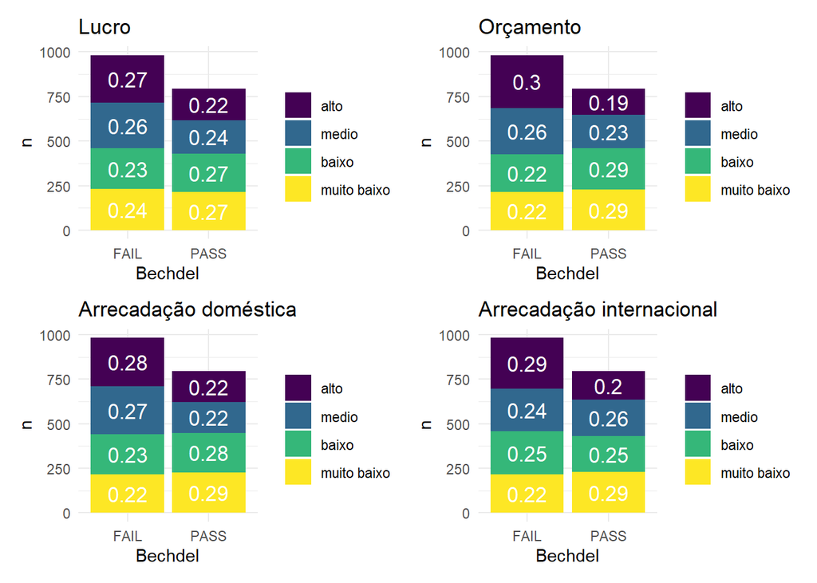

### *Análise ao longo do tempo*

Considerando os anos com ao menos 10 filmes na base, o orçamento médio ao logo dos anos vem aumentando, no entanto o lucro corrigido médio tem tendência de queda. Isso aparentemente se deve ao fato dos filmes mais atuais assumirem mais riscos, aumentando despesas e se inserindo internacionalmente. Isso se confirma no gráfico seguinte, que mostra que o prejuzo médio dos filmes que faturaram abaixo do orçamento tem tendência de aumento.

A boa noticia é que a **taxa de aprovação do teste vem aumentando** com o passar dos anos, reflexo das mudanças sociais e da maior importancia do fomento de igualdade no cimena.

Por fim, os **percentuais de lucro/prejuizo são bem similares** dentro dos grupos de sucesso e fracasso no teste.

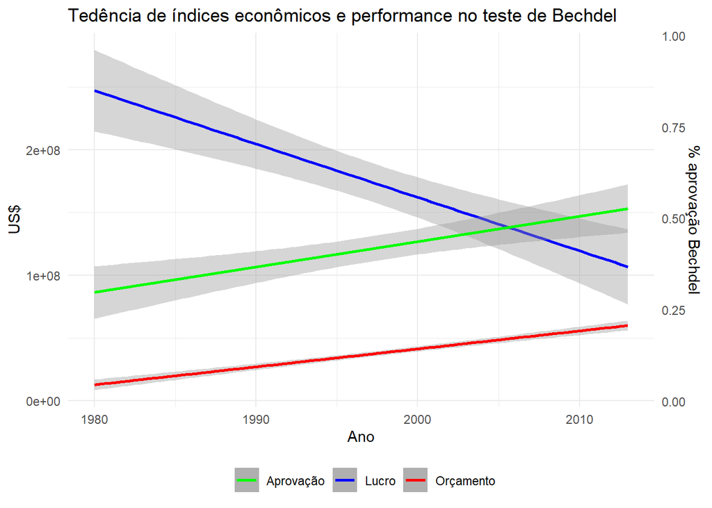

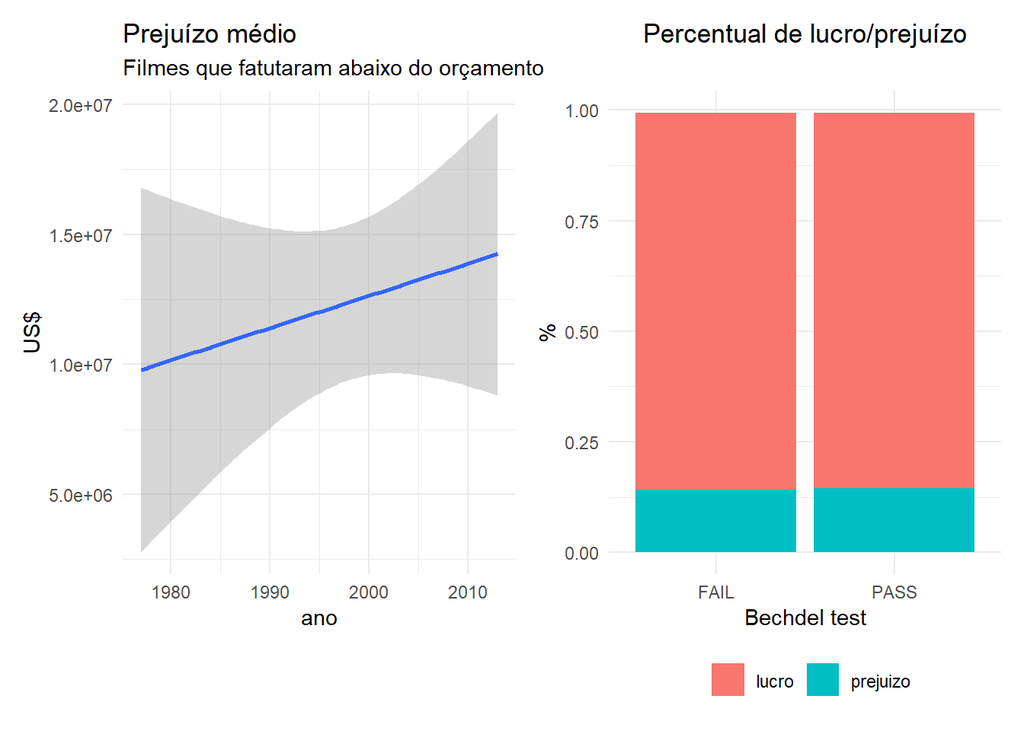

### Concluções

Apesar de uma relação de causa-efeito não ser evidente, filmes com **maiores orçamentos e arrecadações falham mais** no teste de Bechdel, mesmo assim, não há uma discrepância tão grande entre as duas categorias a ponto de afirmar que fatores econômicos são determimantes para o resultado do teste.

É bom resaltar que o **percentual de sucesso no teste tem aumentado** ao longo dos anos, apesar de ainda estar em um percentual longe do ideal, atingindo **pouco mais 50% apenas**.